# NAFTA TradeWatch

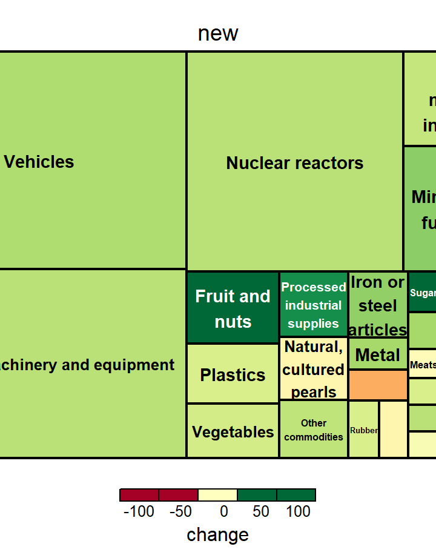

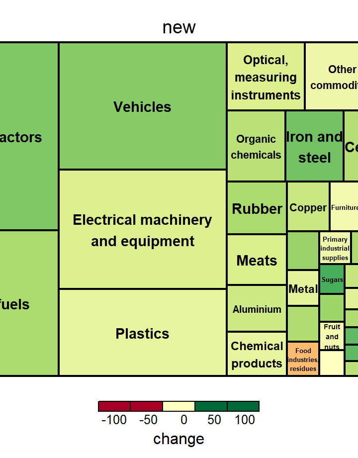

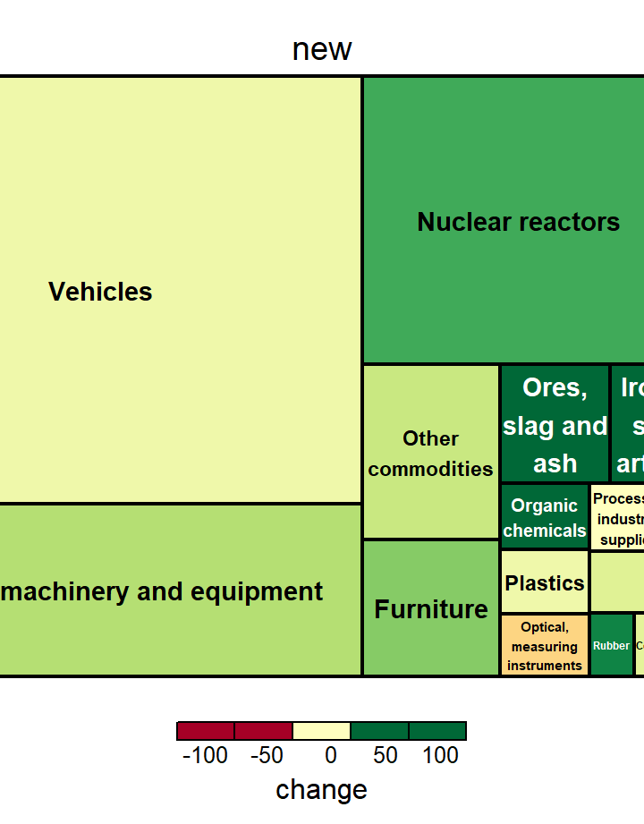

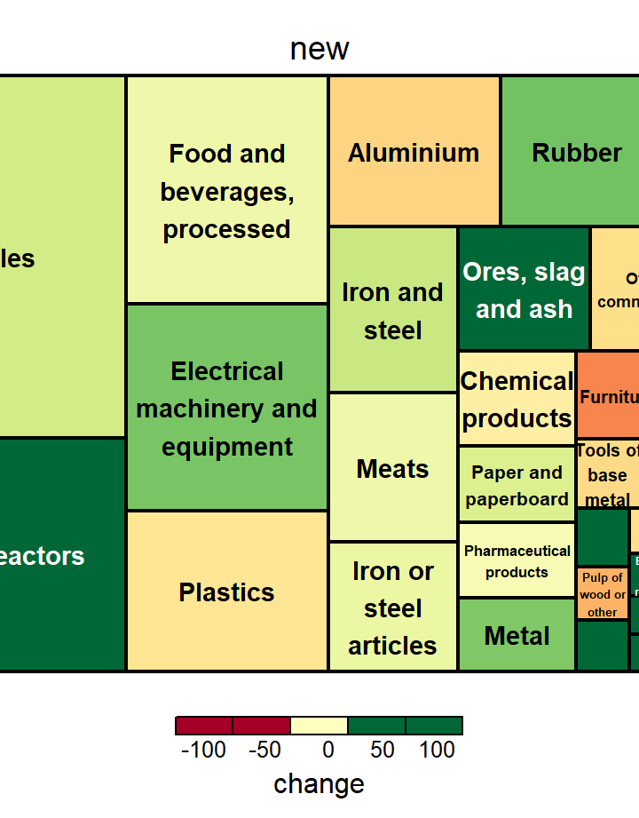

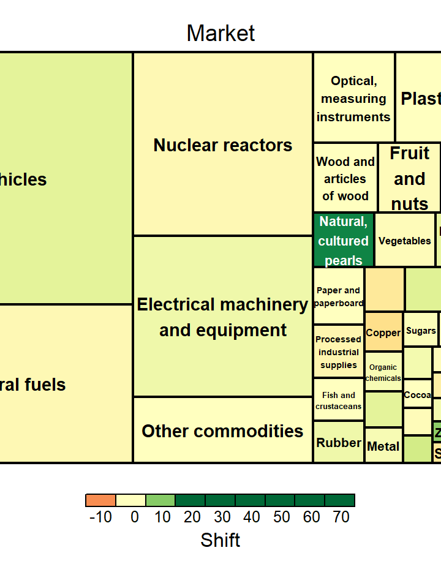

# Mexico - US Trade

### Mexico to USA export matrix

```
[1] 2072
[1] 1036
[1] 2072
[1] 532
```

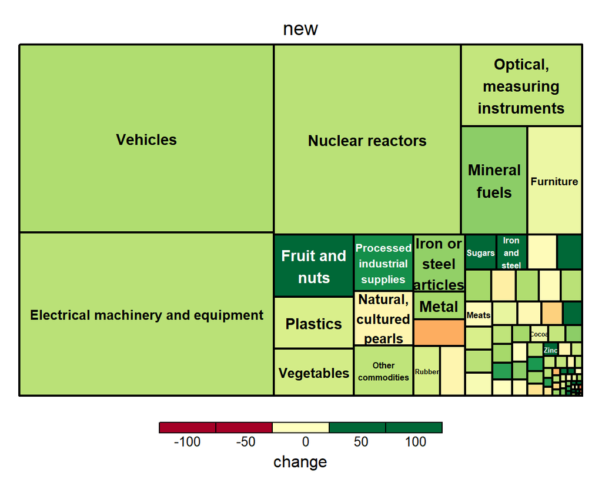

[interactive chart not shown]

> HS 4-Level Codes with a smaller trade value than 1 million usd dollars in latest month are grouped and labeled as “smaller”. Source: UN Comtrade.

### Total Mexican exports to USA

[interactive chart not shown]

> Source: INEGI.

### Mexico from USA import matrix

```
[1] 2271
[1] 1141
[1] 2271
[1] 609
```

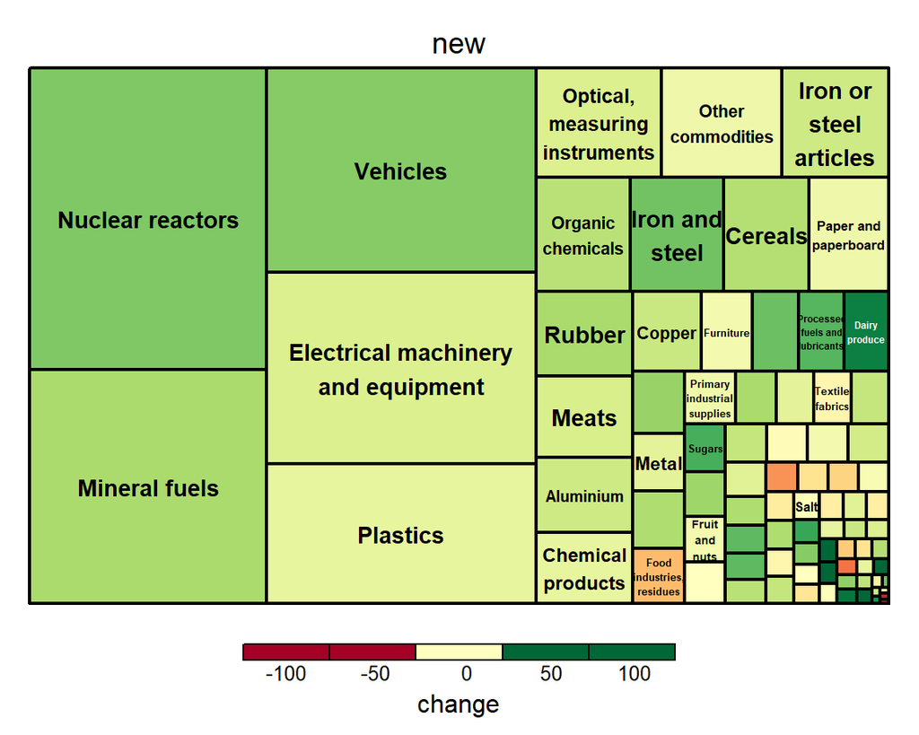

[interactive chart not shown]

> HS 4-Level Codes with a smaller trade value than 1 million usd dollars in latest month are grouped and labeled as “smaller”. Source: UN Comtrade.

### Total Mexican imports from USA

[interactive chart not shown]

> Source: INEGI.

# Mexico - Canada Trade

### Mexico to Canada export matrix

```
[1] 1016
[1] 525
[1] 1016
[1] 92
```

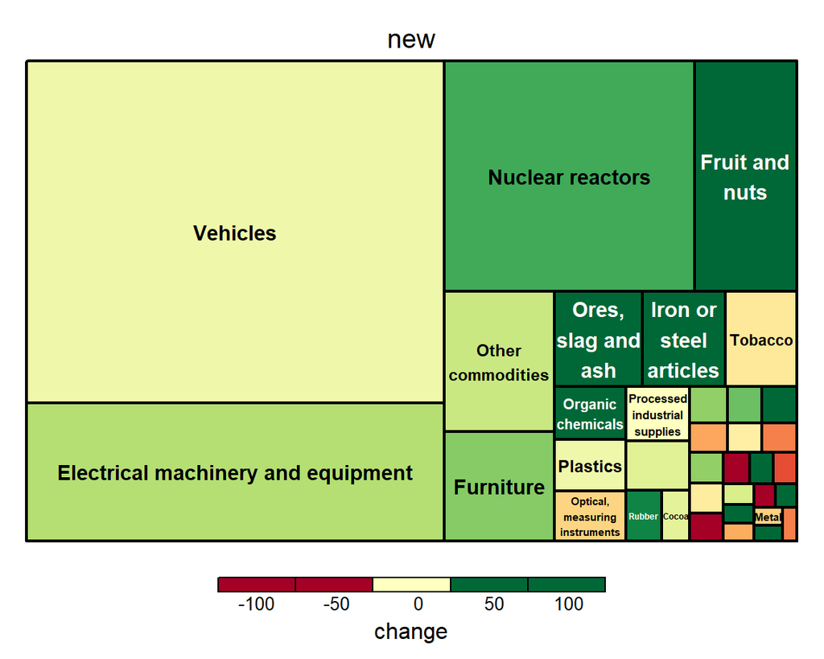

[interactive chart not shown]

> HS 4-Level Codes with a smaller trade value than 1 million usd dollars in latest month are grouped and labeled as “smaller”. Source: UN Comtrade.

### Total Mexican exports to Canada

[interactive chart not shown]

> Source: INEGI.

### Mexico from Canada import matrix

```
[1] 1370
[1] 674
[1] 1370
[1] 128
```

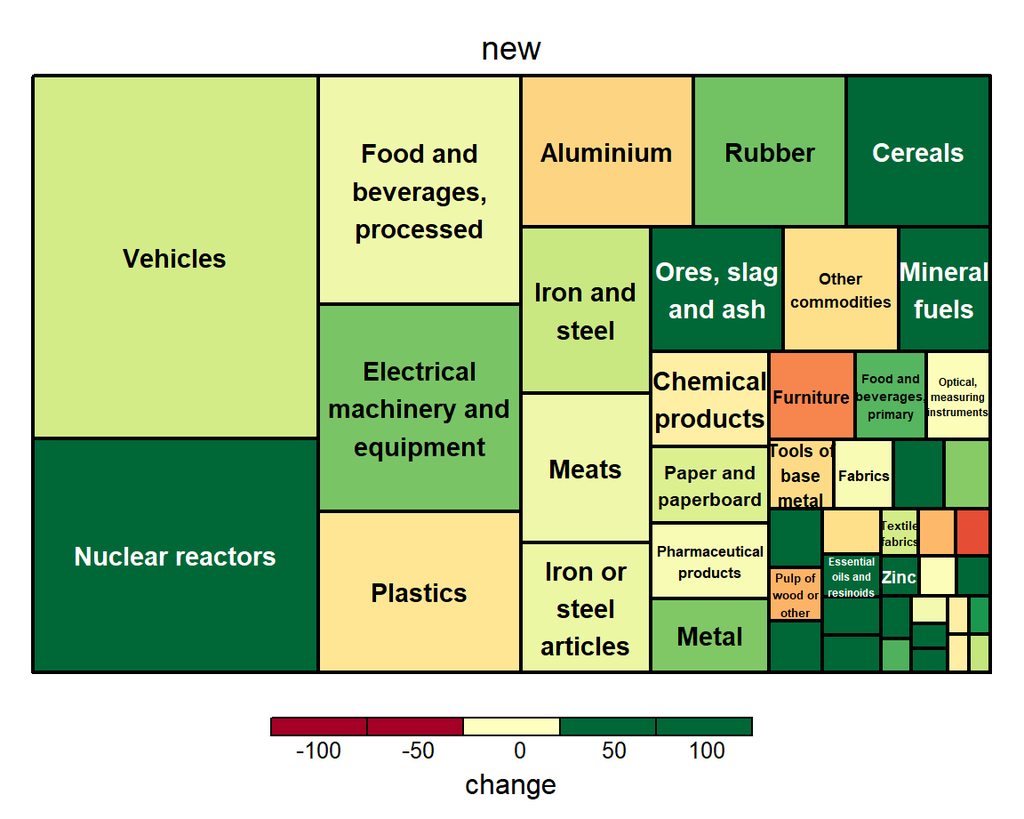

[interactive chart not shown]

> HS 4-Level Codes with a smaller trade value than 1 million usd dollars in latest month are grouped and labeled as “smaller”. Source: UN Comtrade.

### Total Mexican imports from Canada

[interactive chart not shown]

> Source: INEGI.

# US Share-Shift

### Changes of share of Mexican products in U.S. Market

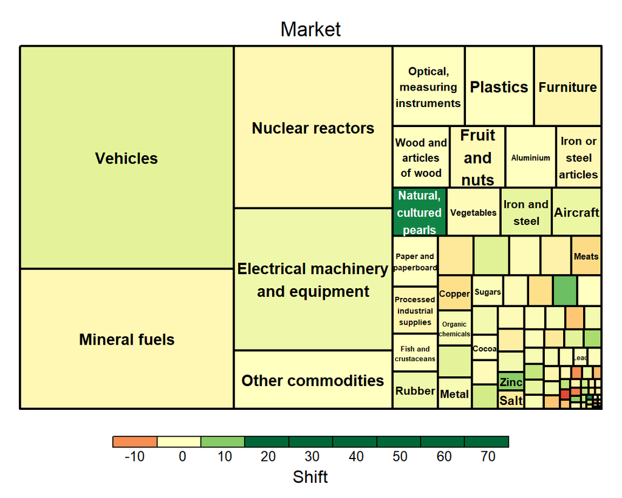

[interactive chart not shown]

> Imports are not collectively exhaustive (the U.S. market is represented by only the two other NAFTA countries). Source: UN Comtrade.

# Terms of Trade & Fx

### MXN-USD Exchange Rate

[interactive chart not shown]

> Source: Federal Reserve Bank of St. Louis.

### USD Trade-weighted exchange rate

[interactive chart not shown]

> Broad measure. Source: Federal Reserve Bank of St. Louis.

### Mexican Import Price Index

[interactive chart not shown]

> Source: Federal Reserve Bank of St. Louis.

### Canada Import Price Index

[interactive chart not shown]

> Source: Federal Reserve Bank of St. Louis.